# My Mutiple Logistic Regression

William Miller

## Background

This analysis is the “part 2” of and original analysis which was created to see if population could predict whether an area is a Metro area or not. The study uses demographic data collected from the Midwest region of the United States. The dataset contained 437 rows and 28 variables ranging from population by race, and so on. To help concentrate the analysis a little more on specific data, a sub dataset was created, and is presented below.

```r
datatable(midwest[c("county", "state", "poptotal", "percbelowpoverty", "percprof", "inmetro")], options = list(pagelength = 5, dom = 'tip'), class = 'cell-border stripe')
```

|  | county | state | poptotal | percbelowpoverty | percprof | inmetro |
| --- | --- | --- | --- | --- | --- | --- |
| 1 | ADAMS | IL | 66090 | 13.1514428 | 4.35585939 | 0 |
| 2 | ALEXANDER | IL | 10626 | 32.2442777 | 2.87031529 | 0 |
| 3 | BOND | IL | 14991 | 12.0688444 | 4.48857172 | 0 |
| 4 | BOONE | IL | 30806 | 7.20901869 | 4.19779992 | 1 |
| 5 | BROWN | IL | 5836 | 13.5202492 | 3.36768032 | 0 |
| 6 | BUREAU | IL | 35688 | 10.3996354 | 3.27589149 | 0 |
| 7 | CALHOUN | IL | 5322 | 15.1497806 | 3.20960089 | 0 |
| 8 | CARROLL | IL | 16805 | 11.7107262 | 3.05572728 | 0 |
| 9 | CASS | IL | 13437 | 13.875086 | 3.20679887 | 0 |
| 10 | CHAMPAIGN | IL | 173025 | 15.5724373 | 17.7574476 | 1 |

[output cut: 427 more lines]

### Question and Hypothesis

From the data set which has be provided, and based off of the previous analysis conducted the question is presented if the percent of people living below the poverty level, and the percent of people with professions can also help us to see the probability of whether the area is a Metro?

**Model:**

**Variables:**

| Variable | Value | Explanation |
| --- | --- | --- |
| $x_{i1}$ | poptotal | Population of Area |
| $x_{i22}$ | `percbelowpoverty` | Percent of Population Below Poverty Level |
| $x_{i23}$ | `percprof` | Percent of Population with a Profession |

$Y_1 = 1$ will denote the area is Metro, and $Y_2 = 0$ denotes that the area is not Metro.

**Hypothesis:**

$$H_0: \beta_0 = 0$$
$$H_a: \beta_0 \neq 0$$

$$H_0: \beta_1 = 0$$
$$H_a: \beta_1 \neq 0$$

$$H_0: \beta_2 = 0$$
$$H_a: \beta_2 \neq 0$$

## Analysis

**Multiple Logistical Regression:**

```r
demograph1 <- glm(inmetro ~ poptotal + percbelowpoverty + percprof, data = midwest, family = binomial )
pander(summary(demograph1))
```

|  | Estimate | Std. Error | z value | Pr(>\|z\|) |
| --- | --- | --- | --- | --- |
| **(Intercept)** | -1.548 | 0.6052 | -2.557 | 0.01055 |
| **poptotal** | 4.316e-05 | 5.519e-06 | 7.821 | 5.222e-15 |
| **percbelowpoverty** | -0.2124 | 0.04392 | -4.835 | 1.328e-06 |
| **percprof** | 0.1916 | 0.09195 | 2.084 | 0.03716 |

(Dispersion parameter for binomial family taken to be 1 )

| Null deviance: | 562.1 on 436 degrees of freedom |
| --- | --- |
| Residual deviance: | 269.5 on 433 degrees of freedom |

See the end of the document for an interpretation on the resulting data.

```r
pander(hoslem.test(demograph1$y, demograph1$fitted))
```

Hosmer and Lemeshow goodness of fit (GOF) test: `demograph1$y, demograph1$fitted`

| Test statistic | df | P value |
| --- | --- | --- |
| 5.408 | 8 | 0.7133 |

**Visiualization of Model:**

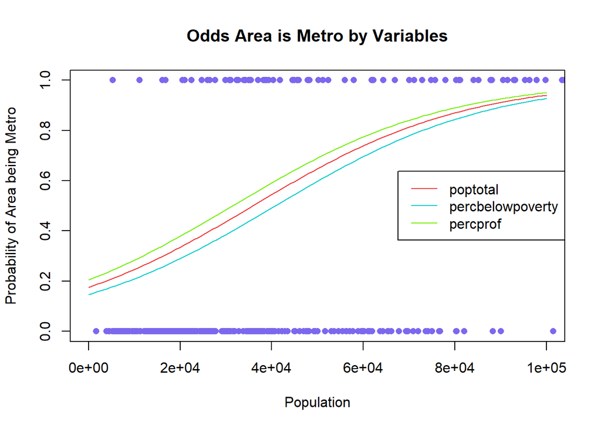

```r
plot(inmetro ~ poptotal, data = midwest, xlim = c(0, 1e+05), ylab = "Probability of Area being Metro", xlab = "Population", main = "Odds Area is Metro by Variables", col = "mediumslateblue", pch = 16)
curve(exp(-1.548e+00+4.316e-05*x)/(1+exp(-1.548e+00+4.316e-05*x)), from=0, to=1e+05, add=TRUE, col = "blueviolet")
curve(exp(-1.548e+00+4.316e-05 + 4.316e-05*x)/(1+exp(-1.548e+00+4.316e-05 + 4.316e-05*x)), from=0, to=1e+05, add=TRUE, col = "brown2")
curve(exp(-1.548e+00-2.124e-01 + 4.316e-05*x)/(1+exp(-1.548e+00-2.124e-01 + 4.316e-05*x)), from=0, to=1e+05, add=TRUE, col = "cyan3")
curve(exp(-1.548e+00+1.916e-01 + 4.316e-05*x)/(1+exp(-1.548e+00+1.916e-01 + 4.316e-05*x)), from=0, to=1e+05, add=TRUE, col = "chartreuse2")
legend("right", legend=paste(c("poptotal", "percbelowpoverty", "percprof")), col=c("brown2","cyan3","chartreuse2"), lty=1)
```

## Interpretation

The data which we received after conducting the Logistical Regression help us to understand the interaction between `inmetro` (Metro Area) and `poptotal` (total population), `percbelowpoverty` (percent of population living below poverty line), `percprof` (percent of population with a profession).

We can see that the effect of `poptotal` on given level was $e^{4.316e-05} = 1.0000432$. This shows that the odds of the area being Metro is higher when there is a larger population than a lower population.

We interpret the `percbelowpoverty` as the effect that poverty and/or income will have on the odds that an area is a Metro or not. The data we received on that was, $e^{-0.2124} = 0.8086412$. We can see that there is a 20% less chance that the area will be Metro if the person lives below the poverty level.

We interpret the `percprof` as the effect that the precent of the population having a profession has on the odds of the area being Metro. The data for this variable was, $e^{0.1916} = 1.2111859$. From this we see there is a 20% more chance that the area is Metro if there is a high percent of the population having a profession.

Overall from this analysis we are establishing a more effective model to predict the demographic of an area based off certain variables. The ones I selected are only a few of the possible variables that can predict if the area is Metro, however this analysis has provided us with a somewhat effective model for determining if the area is Metro or not.